# Minimum_spanning_tree

عنوان: درخت پوشاننده‌ی حداقلی[1]  
دانشجو: حبیب عزت‌آبادی

حداقل درخت پوشا گونه خاصی از درخت است که طول (یا "وزن") یال‌های درخت را به حداقل می رساند. یک مثال ساده یک شرکت کابلی است که می خواهد به چندین محله خط بکشد. با به حداقل رساندن میزان کابل کشیده شده، شرکت کابل در هزینه صرفه جویی خواهد کرد.

یک درخت دارای یک مسیر است که به هر دو رأس می پیوندد. درخت فراگیر یک گراف درختی است که  
شامل تمام رئوس نمودار اصلی است. به تمام رئوس می رسد. غیر چرخه ای است. به عبارت دیگر، گراف هیچ گره ای ندارد که به خودش حلقه بزند.

```r
library(tidyverse)
library(magick)
```

```r
P <- ggdraw() +
    draw_image(file.choose())
```

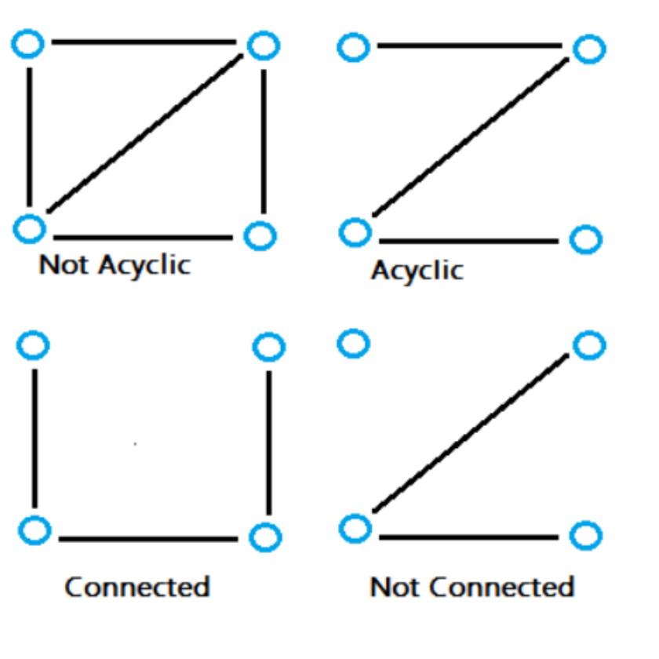

```r
P
```

حتی ساده‌ترین گراف‌ها هم، می‌توانند درختان پوشاننده‌ی زیادی داشته باشند، به مثال زیر توجه کنید.

```r
P2 <- ggdraw() +
    draw_image(file.choose())
```

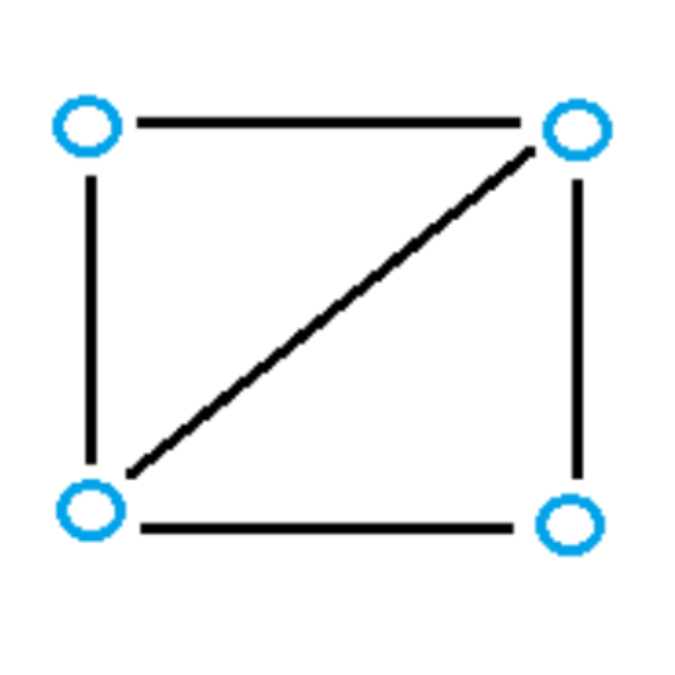

```r
P2
```

از دل همین گراف ساده، می‌توان درختان پوشای زیادی بوجود آورد.

همانطور که احتمالاً می توانید تصور کنید، گراف‌های بزرگتر گره های بیشتری دارند و امکانات بیشتری برای زیرگراف ها دارند. تعداد زیرگراف‌ها می‌تواند به سرعت به میلیون‌ها یا میلیاردها برسد، که یافتن حداقل درخت پوشا را بسیار دشوار (و گاهی غیرممکن) می‌کند. علاوه بر این، طول ها معمولا وزن های متفاوتی دارند. به یک لبه به طول 5 متر می توان وزن 5 و دیگری با همان طول را می توان وزن 7 داد.

چند الگوریتم معروف برای پیدا کردن درخت پوشای حداقلی وجود دارد که از جمله‌ی آن می‌توان موارد زیر را نام برد.

الگوریتم کروسکال[2]

الگوریتم پرایم[3]

الگوریتم بوروکا [4]

قطعا اگه تعداد یال‌های و یا رأس‌ها زیاد باشد، به صورت دستی این کار خیلی دشوار خواهد بود و نیاز به نرم افزار هست.

**الگوریتم کروسکال با یک مثال**  
ابتدا یال با کمترین وزن را پیدا کنید و آن را هایلایت کنید. برای این مثال، یال بالایی (از A تا C) را با رنگ قرمز برجسته کرده ام. دارای کمترین وزن (از 1):

```r
krus1 <- ggdraw() +
    draw_image(file.choose())
```

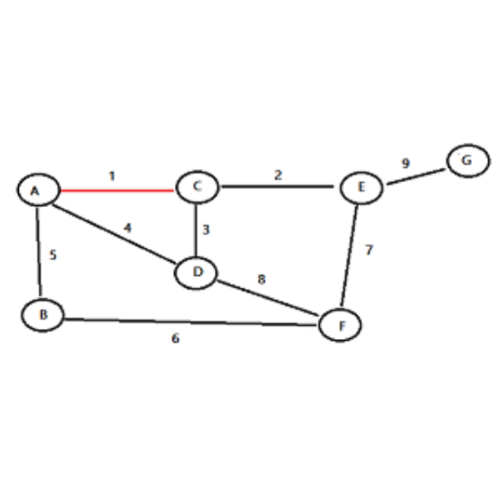

```r
krus1
```

یال بعدی با کمترین وزن را پیدا کنید و آن را هایلایت کنید:

```r
krus2 <- ggdraw() +
    draw_image(file.choose())
```

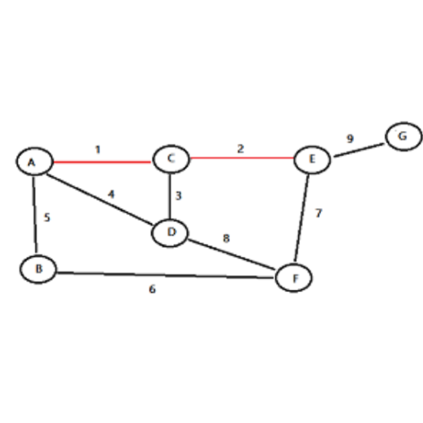

```r
krus2
```

به انتخاب یال‌های با کمترین وزن ادامه دهید تا زمانی که همه گره ها در یک درخت قرار گیرند.

**نکته:**  
اگر بیش از یک یال با وزن یکسان دارید، یال ای را با کمترین وزن انتخاب کنید.  
مراقب باشید که یک چرخه را کامل نکنید (یک گره را به خودش برگردانید). اگر انتخاب شما یک چرخه را کامل می کند، انتخاب خود را کنار بگذارید و به وزن بعدی بروید.  
حداقل درخت پوشا تمام شده برای این مثال به شکل زیر است:

```r
krus3 <- ggdraw() +
    draw_image(file.choose())
```

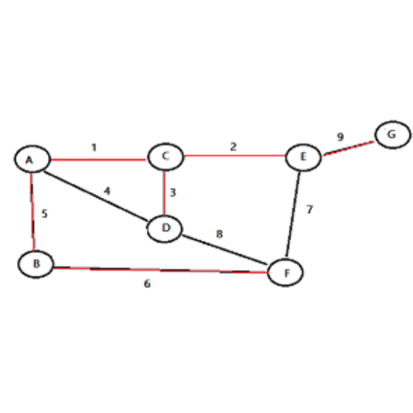

```r
krus3
```

**الگوریتم پرایم:**  
این الگوریتم، یکی دیگر از روش‌های انتخاب درختی حداقلی پوشا می‌باشد.  
روش کار این الگوریتم به شکل زیر هست.

گام اول:  
یک رأس (گره) را به صورت تصادفی انتخاب می‌کنیم و آن‌را هایلایت می‌کنیم. در این مثال ما رأس C را انتخاب کرده‌ایم.

```r
prim1 <- ggdraw() +
    draw_image(file.choose())
```

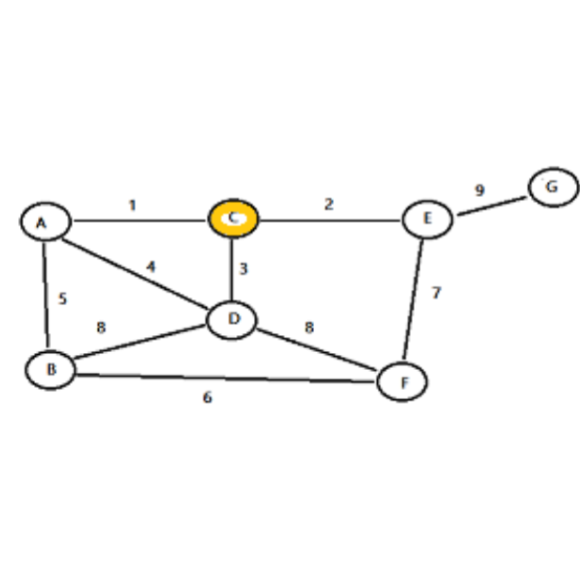

```r
prim1
```

گام دوم:  
تمام یال‌هایی که از این رأس به گره‌های دیگر می‌روند را بررسی کنید و یالی که کمترین وزن را دارد،‌ انتخاب کنید.

```r
prim2 <- ggdraw() +
    draw_image(file.choose())
```

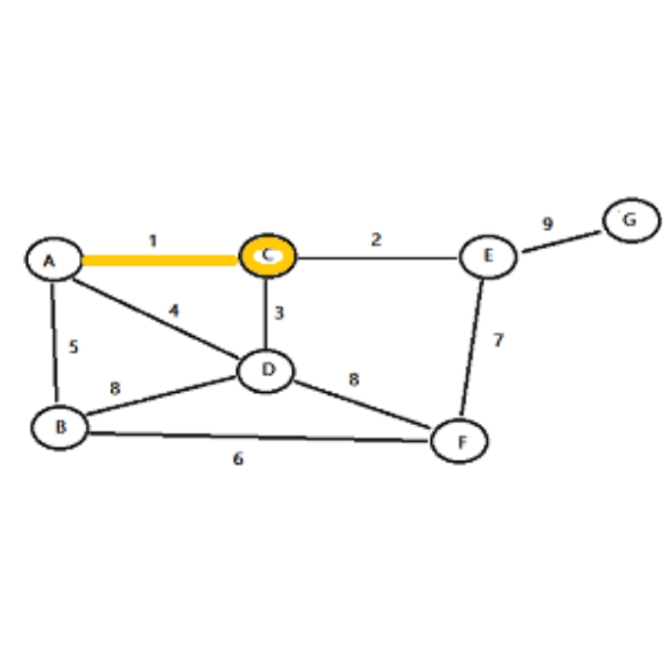

```r
prim2
```

گام سوم:  
رأسی که به تازگی به آن رسیده‌اید را مشخص (هایلایت) کنید. دراینجا رأس A هایلایت می‌شود.

گام چهارم:  
به تمام رأس‌هایی که تا این مرحله‌ انتخاب کرده‌اید، دقت کنید، یال با کمترین وزنی که از A به گره‌های دیگر و یا از گره C به گره‌های دیگر غیر از گره A می‌رود، انتخاب کنید و آن را هایلایت کنید.

```r
prim3 <- ggdraw() +
    draw_image(file.choose())
```

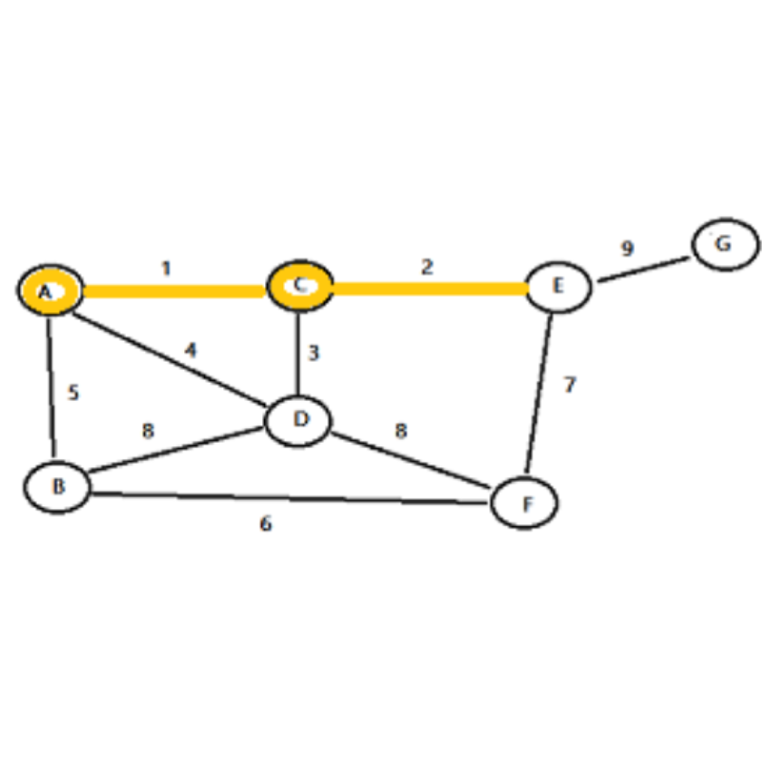

```r
prim3
```

**نکته:**  
اگر یال‌هایی با وزن یکسان دیدید، یک یال را به صورت تصادفی انتخاب کنید.

گام پنجم:  
رأسی که به آن رسیده‌اید را هایلایت کنید.

گام ششم:  
از رأس‌هایی که تا این‌گام انتخاب کرده‌اید، یال‌هایی که به رأس‌های می‌روند که تا این لحظه انتخاب نکرده‌اید را بررسی کنید و یال با کمترین وزن را انتخاب کنید و برجسته کنید.

گام هفتم: گام‌های پنج و شش را اینقدر تکرار کنید، تا دیگر رأسی برای هایلایت شدن باقی نماند. برای مثال بالا مراحل به شکل زیر خواهد بود.

1. رأس E هایلایت می‌شود.
2. لایه‌ی با وزن ۳ انتخاب می‌شود و سپس رأس D انتخاب می‌شود.
3. لایه‌ی با وزن ۵ انتخاب می‌شود و سپس رأس B
4. لایه با وزن ۶ انتخاب می‌شود و سپس رأس F.
5. لایه‌ی با وزن ۹ انتخاب می‌شود و سپس رأس G.

گراف نهایی در شکل زیر نمایش داده شده هست.

```r
prim4 <- ggdraw() +
    draw_image(file.choose())
```

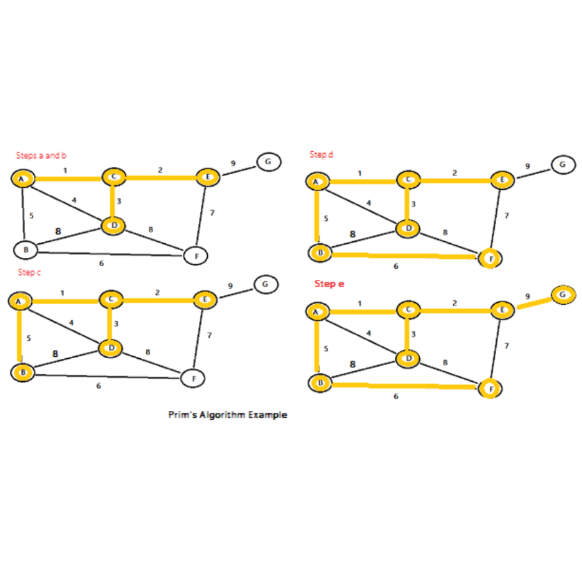

```r
prim4
```

**کاربردها**

1. طراحی شبکه‌های مخابراتی و شبکه‌های کابلی
2. یافتن راه‌حل‌های تقریبی برای مسائل پیچیده‌ی ریاضی مانند مسئله [فروشنده‌ی دوره‌گرد](https://fa.wikipedia.org/wiki/%D9%85%D8%B3%D8%A6%D9%84%D9%87_%D9%81%D8%B1%D9%88%D8%B4%D9%86%D8%AF%D9%87_%D8%AF%D9%88%D8%B1%D9%87%E2%80%8C%DA%AF%D8%B1%D8%AF)
3. آنالیز خوشه‌ای [5]
4. مکان‌یابی چهره‌ی انسان در یک فیلم ویدئویی[6]
5. و غیره ...

مثال در R

```
Multiple layers are present in data source F:\dr_purahmad\spanning_tree\iran_data_map, reading layer `irn_admbnda_adm0_unhcr_20190514'.
Use `st_layers' to list all layer names and their type in a data source.
Set the `layer' argument in `st_read' to read a particular layer.
```

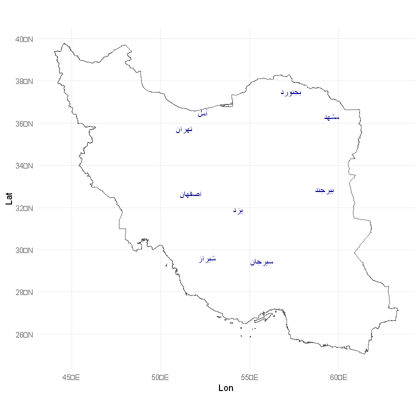

```r
# load packages
library(corrplot)
library(sf)
library(igraph)

# define vertices
city_per <- c("شیراز",
"اصفهان", "آمل",
"بیرجند", "بجنورد", "مشهد", "سیرجان", "تهران", "یزد")


# define latitude and longitude for city
mydat <- data.frame(
    City = city_per,
    Lat = c(29.591768, 32.661343, 36.471546,
    32.83333, 37.4745, 36.310699, 29.45137, 35.7219, 31.8974),
    Lon = c(52.583698, 51.680374, 52.355087, 59.221375,
    57.32903, 59.599457, 55.6809, 51.3347, 54.3569)
)




# read shape file of Province map of Iran

iran <- st_read("F:\\dr_purahmad\\spanning_tree\\iran_data_map")


# create map of iran

ggplot(iran) + geom_sf(fill = NA)  +
theme_minimal() -> map_iran
map_iran +
geom_text(data = mydat,
aes(x = Lon, y = Lat, label = City), color = "darkblue") -> P1
P1
```

```r
# create distance matrix

dist_mat <- matrix(
    c(0, 489, 1110, 1073, 1344, 1354, 387, 920, 441, 489, 0, 609, 870,
    1019, 1147, 627, 436, 323, 1110, 609, 0, 1045, 518, 802, 1147,
    185, 799,
    1073, 870, 1045, 0, 659, 492, 740, 1135, 628,
    1344, 1019, 518, 659, 0,
    274, 1183, 722, 906, 1354, 1147, 802, 492, 274, 0, 1085,
    899, 907,
    387, 627, 1147, 740, 1183, 1085, 0, 969, 351,
    920, 436, 185, 1135,
    722, 899, 969, 0, 621, 441, 323, 799, 628, 906, 907, 351,
    621, 0
    ), 9, 9, dimnames = list(mydat$City, mydat$City)
)
```

```r
check_symmetric_matrix <- function(A){
    n1 <- nrow(A)
    n2 <- ncol(A)
    if(n1 != n2) stop("A must be square matrix")
    S <- c()
    k <- 0
    for(i in 1:n1){
        for(j in 1:n2){
        s <- A[i, j] != A[j, i]
        S[k] <- s
        }
    }
    res <- ifelse(sum(S), "A not Symmetric", "A is Symmetric")
    return(res)
}
check_symmetric_matrix(dist_mat)
```

'A is Symmetric'

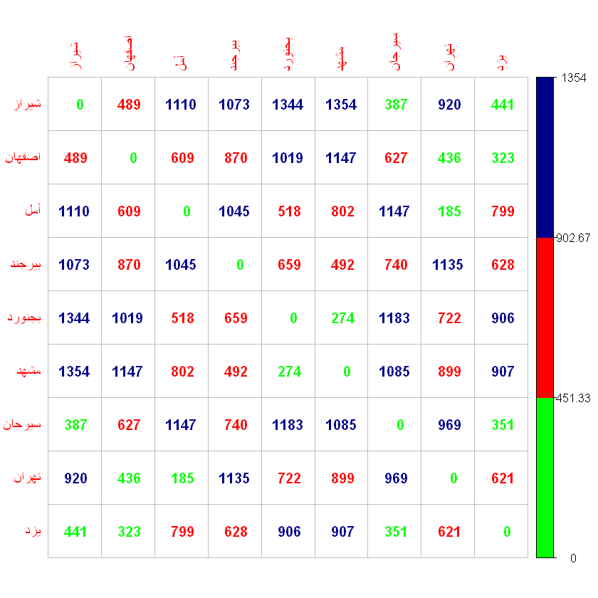

```r
# create a mat distance

corrplot(dist_mat, type = "full",
method = "number",
is.corr = FALSE, col = c("green", "red", "darkblue"),
number.digits = 0)
```

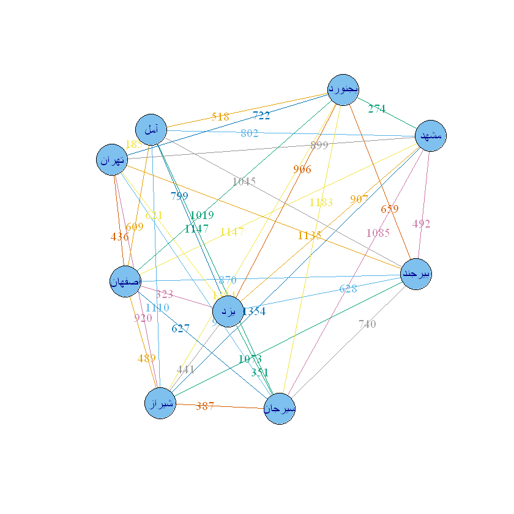

```r
# use igraph for visualize data and implement MST Algorithm

G <- make_empty_graph(n = 9)

V(G)$color <- "skyblue2"
V(G)$size <- 20
coord <- cbind(lon = mydat$Lon, lat = mydat$Lat)
col1 <- c(rep(1, 8), rep(2, 7),
rep(3, 6), rep(4, 5), rep(5, 4), rep(6, 3),
rep(7, 2), 8)
col2 <- c(2:9, 3:9, 4:9, 5:9, 6:9, 7:9, 8:9, 9)
col3 <- c(dist_mat[2:9, 1],
dist_mat[3:9, 2], dist_mat[4:9, 3],
dist_mat[5:9, 4], dist_mat[6:9, 5], dist_mat[7:9, 6],
dist_mat[8:9, 7], dist_mat[9, 8])
names(col1) <- names(col2) <- names(col3) <- NULL
Edge <- numeric(72)
Edge[seq(1, 72, 2)] <- col1
Edge[seq(2, 72, 2)] <- col2

G %>%
  add_edges(Edge) %>%
  set_edge_attr("color", value = "red") -> G
E(G)$weight <- E(G)$label <- col3
V(G)$label = city_per
G <- set_graph_attr(G, "layout", coord)
G <- set_edge_attr(G, "color", value = 1:36)
G <- set_edge_attr(G, "label.color", value = 1:36)
plot.igraph(G, edge.arrow.mode = 0)
```

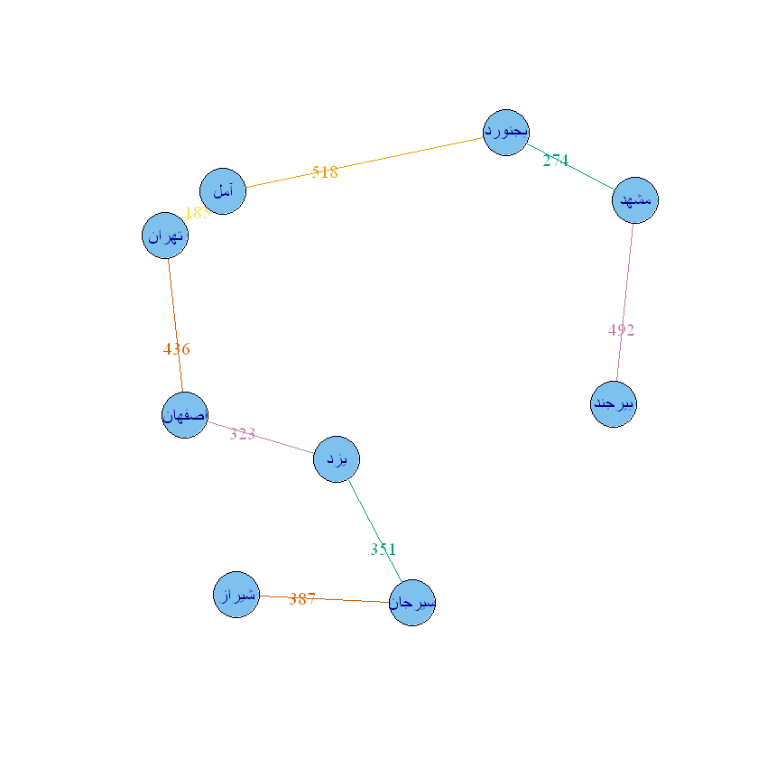

```r
G_mst <- mst(G, algorithm = "prim")
plot.igraph(G_mst, edge.arrow.mode = 0)
```

```r
mydat
```

A data.frame: 9 × 3

| City <chr> | Lat <dbl> | Lon <dbl> |
| --- | --- | --- |
| شیراز | 29.59177 | 52.58370 |
| اصفهان | 32.66134 | 51.68037 |
| آمل | 36.47155 | 52.35509 |
| بیرجند | 32.83333 | 59.22138 |
| بجنورد | 37.47450 | 57.32903 |
| مشهد | 36.31070 | 59.59946 |
| سیرجان | 29.45137 | 55.68090 |
| تهران | 35.72190 | 51.33470 |
| یزد | 31.89740 | 54.35690 |

```r
ind <- c(1, 7, 9, 2, 8, 3, 5, 6, 4)
mydat %>%
slice(ind) -> newdat
newdat
```

A data.frame: 9 × 3

| City <chr> | Lat <dbl> | Lon <dbl> |
| --- | --- | --- |
| شیراز | 29.59177 | 52.58370 |
| سیرجان | 29.45137 | 55.68090 |
| یزد | 31.89740 | 54.35690 |
| اصفهان | 32.66134 | 51.68037 |
| تهران | 35.72190 | 51.33470 |
| آمل | 36.47155 | 52.35509 |
| بجنورد | 37.47450 | 57.32903 |
| مشهد | 36.31070 | 59.59946 |
| بیرجند | 32.83333 | 59.22138 |

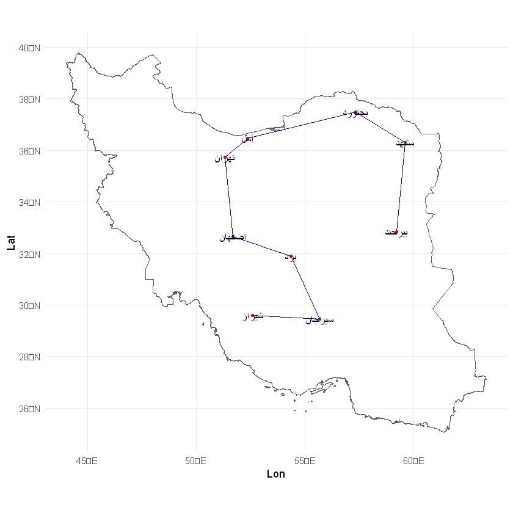

```r
map_iran +
geom_point(data = newdat, aes(x = Lon, y = Lat), size = 1, colour = "red", shape = 19) +
geom_text(data = newdat, aes(x = Lon, y = Lat, label = City)) -> P2
for(i in 1:8){
    P2 <- P2 + annotate(geom = "segment", newdat$Lon[i], y = newdat$Lat[i], xend = newdat$Lon[i+1],
    yend = newdat$Lat[i+1], colour = "blue")
}
P2
```

[1] Minimum Spannig Tree

[2] Kruskal’s algorithm

[3] Prim’s algorithm

[4] Boruvka’s algorithm

[5] Cluster Analysis

[6] Real-time face tracking and verification.